# Mini Project: Monte Carlo Methods

In this notebook, you will write your own implementations of many Monte Carlo (MC) algorithms.

While we have provided some starter code, you are welcome to erase these hints and write your code from scratch.

### Part 0: Explore BlackjackEnv

Use the code cell below to create an instance of the [Blackjack](https://github.com/openai/gym/blob/master/gym/envs/toy_text/blackjack.py) environment.

```python
import gym
from collections import defaultdict
import numpy as np
import sys
from plot_utils import plot_blackjack_values
from plot_utils import plot_policy


env = gym.make('Blackjack-v0')
```

Each state is a 3-tuple of:

- the player's current sum $\in \{0, 1, \ldots, 31\}$,
- the dealer's face up card $\in \{1, \ldots, 10\}$, and
- whether or not the player has a usable ace (`no` $=0$, `yes` $=1$).

The agent has two potential actions:

```
    STICK = 0
    HIT = 1
```

Verify this by running the code cell below.

```python
print(env.observation_space)
print(env.action_space)
```

```
Tuple(Discrete(32), Discrete(11), Discrete(2))
Discrete(2)
```

Execute the code cell below to play Blackjack with a random policy.

```python
for i_episode in range(10):
    state = env.reset()
    while True:
        print(state)
        action = env.action_space.sample()
        state, reward, done, info = env.step(action)
        if done:
            print('End game! Reward: ', reward)
            print('You won :)\n') if reward > 0 else print('You lost :(\n')
            break
```

```
(15, 2, False)
End game! Reward:  -1.0
You lost :(

(13, 3, False)
End game! Reward:  -1
You lost :(

(20, 7, False)
End game! Reward:  -1
You lost :(

(12, 1, False)
End game! Reward:  1.0
You won :)

(14, 5, False)
(16, 5, False)
(18, 5, False)
(20, 5, False)
End game! Reward:  -1
You lost :(

(15, 10, False)
(19, 10, False)
End game! Reward:  -1
You lost :(

(19, 10, False)
End game! Reward:  -1
You lost :(

(17, 7, False)
End game! Reward:  0.0
You lost :(

(14, 10, False)
End game! Reward:  -1.0
You lost :(

(8, 2, False)
(13, 2, False)
End game! Reward:  1.0
You won :)
```

### Part 1: MC Prediction: State Values

In this section, you will write your own implementation of MC prediction (for estimating the state-value function).

We will begin by investigating a policy where the player always sticks if the sum of her cards exceeds 18. The function `generate_episode_from_limit` samples an episode using this policy.

The function accepts as **input**:

- `bj_env`: This is an instance of OpenAI Gym's Blackjack environment.

It returns as **output**:

- `episode`: This is a list of (state, action, reward) tuples (of tuples) and corresponds to $(S_0, A_0, R_1, \ldots, S_{T-1}, A_{T-1}, R_{T})$, where $T$ is the final time step. In particular, `episode[i]` returns $(S_i, A_i, R_{i+1})$, and `episode[i][0]`, `episode[i][1]`, and `episode[i][2]` return $S_i$, $A_i$, and $R_{i+1}$, respectively.

```python
def generate_episode_from_limit(bj_env, limit=18):
    episode = []
    state = bj_env.reset()
    while True:
        action = 0 if state[0] > limit else 1
        next_state, reward, done, info = bj_env.step(action)
        episode.append((state, action, reward))
        state = next_state
        if done:
            break
    return episode
```

Execute the code cell below to play Blackjack with the policy.

```python
for i in range(10):
    print(generate_episode_from_limit(env))
```

```
[((12, 10, True), 1, 0), ((21, 10, True), 0, 1.0)]
[((16, 2, False), 1, -1)]
[((8, 10, False), 1, 0), ((18, 10, False), 1, -1)]
[((17, 5, False), 1, -1)]
[((13, 7, False), 1, 0), ((16, 7, False), 1, -1)]
[((14, 2, True), 1, 0), ((14, 2, False), 1, 0), ((18, 2, False), 1, -1)]
[((18, 10, False), 1, -1)]
[((18, 5, False), 1, 0), ((20, 5, False), 0, 1.0)]
[((13, 10, False), 1, -1)]
[((12, 10, True), 1, 0), ((19, 10, True), 0, -1.0)]
```

Now, you are ready to write your own implementation of MC prediction. Feel free to implement either first-visit or every-visit MC prediction; in the case of the Blackjack environment, the techniques are equivalent.

- `env`: This is an instance of an OpenAI Gym environment.
- `num_episodes`: This is the number of episodes that are generated through agent-environment interaction.
- `generate_episode`: This is a function that returns an episode of interaction.
- `gamma`: This is the discount rate. It must be a value between 0 and 1, inclusive (default value: `1`).

The algorithm returns as output:

- `V`: This is a dictionary where `V[s]` is the estimated value of state `s`. For example, if your code returns the following output:

  ```
  {(4, 7, False): -0.38775510204081631, (18, 6, False): -0.58434296365330851, (13, 2, False): -0.43409090909090908, (6, 7, False): -0.3783783783783784, ...
  ```

  then the value of state `(4, 7, False)` was estimated to be `-0.38775510204081631`.

If you are unfamiliar with how to use `defaultdict` in Python, you are encouraged to check out [this source](https://www.accelebrate.com/blog/using-defaultdict-python/).

```python
def mc_prediction_v(env, num_episodes, generate_episode, gamma=1.0, limit=18):
    '''
    Takes the environment and number of episodes, along with some optional inputs,
    and returns a dictionary of values.
    '''
    # initialize empty dictionary of lists
    returns = defaultdict(list)
    # loop over episodes
    for i_episode in range(1, num_episodes+1):
        # monitor progress
        if i_episode % 1000 == 0:
            print("\rEpisode {}/{}.".format(i_episode, num_episodes), end="")
            sys.stdout.flush()

        ## TODONE: complete the function
        episode = generate_episode(env, limit)

        # Unzip the States, Actions and Rewards from the episode
        S, A, R = zip(*episode)

        # Get a discount array based on the current gamma
        G = np.array([gamma ** t for t in range(1+len(R))])

        # Obtain the First-Visit MC prediction
        for t in range(len(S)):
            r = sum(R[t:] * G[:-(1+t)])
            if [(S[t], r)] not in returns.items():
                returns[S[t]].append(r)

#         # Solution code's method that obtains the First-Visit MC
#         for t, s in enumerate(S):
#             returns[s].append(sum(R[t:] * G[:-(1+t)]))

    # Average the value for each state
    V = {key: np.mean(v) for key, v in returns.items()}

    return V
```

Use the cell below to calculate and plot the state-value function estimate. (*The code for plotting the value function has been borrowed from [this source](https://github.com/dennybritz/reinforcement-learning/blob/master/lib/plotting.py) and slightly adapted.*)

To check the accuracy of your implementation, compare the plot below to the corresponding plot in the solutions notebook **Monte_Carlo_Solution.ipynb**.

```
Episode 50000/50000.
```

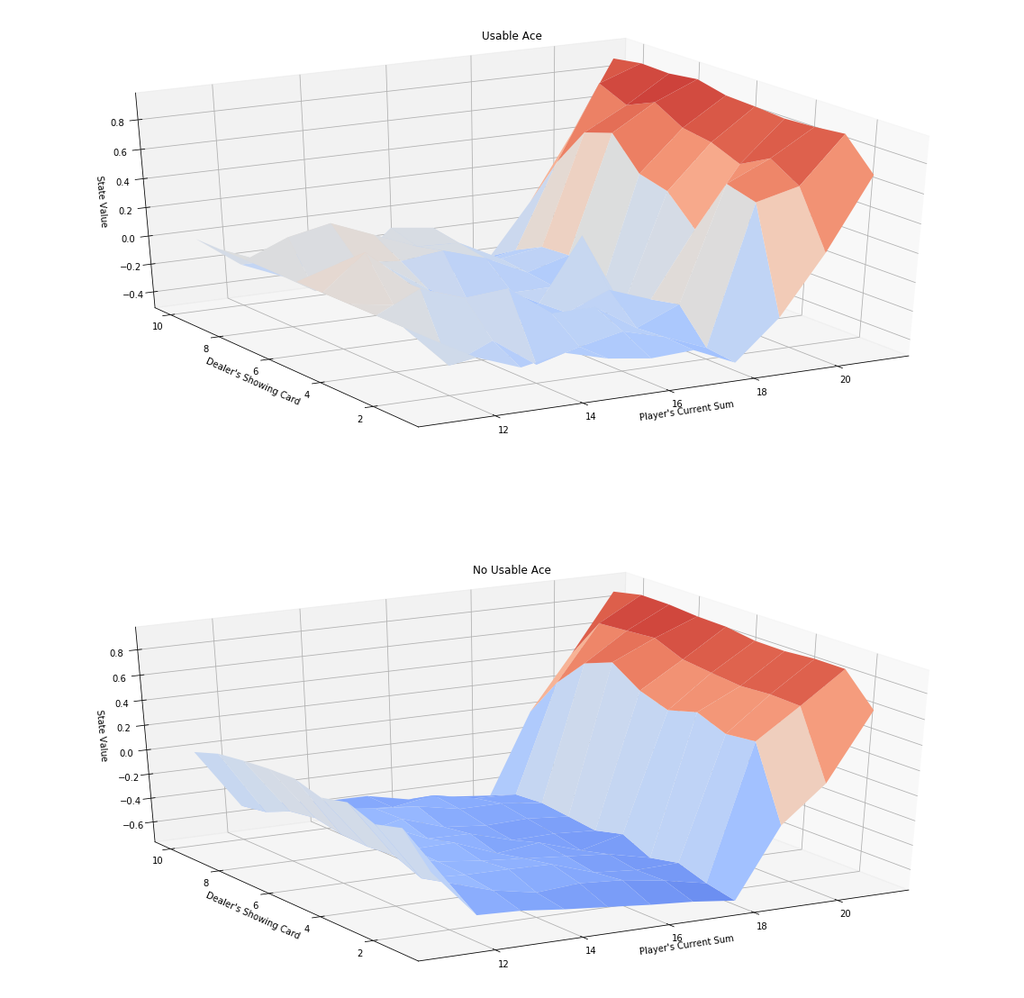

```python
# obtain the value function
V = mc_prediction_v(env, 50000, generate_episode_from_limit)

# plot the value function
plot_blackjack_values(V)
```

### Part 2: MC Prediction: Action Values

In this section, you will write your own implementation of MC prediction (for estimating the action-value function).

We will begin by investigating a policy where the player *almost* always sticks if the sum of her cards exceeds 18. In particular, she selects action `STICK` with 80% probability if the sum is greater than 18; and, if the sum is 18 or below, she selects action `HIT` with 80% probability. The function `generate_episode_from_limit_stochastic` samples an episode using this policy.

The function accepts as **input**:

- `bj_env`: This is an instance of OpenAI Gym's Blackjack environment.

It returns as **output**:

- `episode`: This is a list of (state, action, reward) tuples (of tuples) and corresponds to $(S_0, A_0, R_1, \ldots, S_{T-1}, A_{T-1}, R_{T})$, where $T$ is the final time step. In particular, `episode[i]` returns $(S_i, A_i, R_{i+1})$, and `episode[i][0]`, `episode[i][1]`, and `episode[i][2]` return $S_i$, $A_i$, and $R_{i+1}$, respectively.

```python
def generate_episode_from_limit_stochastic(bj_env, limit=18, probability=0.8):
    episode = []
    state = bj_env.reset()
    while True:
        probs = [probability, 1-probability] if state[0] > limit else [1-probability, probability]
        action = np.random.choice(np.arange(2), p=probs)
        next_state, reward, done, info = bj_env.step(action)
        episode.append((state, action, reward))
        state = next_state
        if done:
            break
    return episode
```

Now, you are ready to write your own implementation of MC prediction. Feel free to implement either first-visit or every-visit MC prediction; in the case of the Blackjack environment, the techniques are equivalent.

- `env`: This is an instance of an OpenAI Gym environment.
- `num_episodes`: This is the number of episodes that are generated through agent-environment interaction.
- `generate_episode`: This is a function that returns an episode of interaction.
- `gamma`: This is the discount rate. It must be a value between 0 and 1, inclusive (default value: `1`).

The algorithm returns as output:

- `Q`: This is a dictionary (of one-dimensional arrays) where `Q[s][a]` is the estimated action value corresponding to state `s` and action `a`.

```python
def mc_prediction_q(env, num_episodes, generate_episode, gamma=1.0, limit=18, probability=0.8):
    '''
    Takes the environment and number of episodes, along with some optional inputs,
    and returns a reward estimate that will eventually converge on optimal.
    '''
    # initialize empty dictionaries of arrays
    returns_sum = defaultdict(lambda: np.zeros(env.action_space.n))
    N = defaultdict(lambda: np.zeros(env.action_space.n))
    Q = defaultdict(lambda: np.zeros(env.action_space.n))
    # loop over episodes
    for i_episode in range(1, num_episodes+1):
        # monitor progress
        if i_episode % 1000 == 0:
            print("\rEpisode {}/{}.".format(i_episode, num_episodes), end="")
            sys.stdout.flush()

        ## TODONE: complete the function

        # Generate an episode according to the generate_episode function passed
        episode = generate_episode(env, limit, probability)

        # Unzip the States, Actions and Rewards from the episode
        S, A, R = zip(*episode)

        # Get a discount array based on the current gamma
        G = np.array([gamma ** t for t in range(1+len(R))])

        # Obtain the first visit MC prediction
        for t, s in enumerate(S):
            returns_sum[s][A[t]] += sum(R[t:] * G[:-(1+t)])
            N[s][A[t]] += 1.
            Q[s][A[t]] = returns_sum[s][A[t]] / N[s][A[t]]

    return Q
```

Use the cell below to obtain the action-value function estimate $Q$. We have also plotted the corresponding state-value function.

To check the accuracy of your implementation, compare the plot below to the corresponding plot in the solutions notebook **Monte_Carlo_Solution.ipynb**.

```
Episode 50000/50000.
```

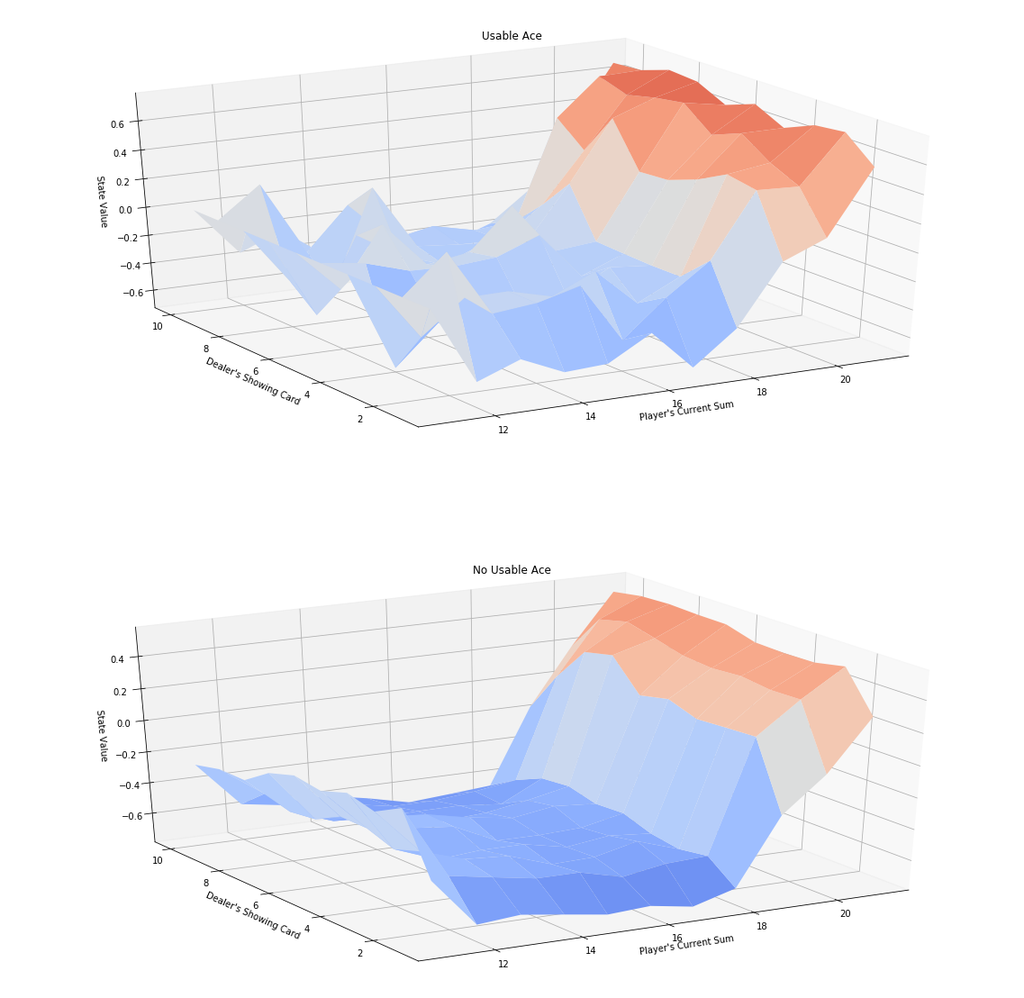

```python
# obtain the action-value function
Q = mc_prediction_q(env, 50000, generate_episode_from_limit_stochastic)

# obtain the state-value function
V_to_plot = dict((k,(k[0]>18)*(np.dot([0.8, 0.2],v)) + (k[0]<=18)*(np.dot([0.2, 0.8],v))) \
         for k, v in Q.items())

# plot the state-value function
plot_blackjack_values(V_to_plot)
```

### Part 3: MC Control: GLIE

Your algorithm has three arguments:

- `env`: This is an instance of an OpenAI Gym environment.
- `num_episodes`: This is the number of episodes that are generated through agent-environment interaction.
- `gamma`: This is the discount rate. It must be a value between 0 and 1, inclusive (default value: `1`).

The algorithm returns as output:

- `Q`: This is a dictionary (of one-dimensional arrays) where `Q[s][a]` is the estimated action value corresponding to state `s` and action `a`.
- `policy`: This is a dictionary where `policy[s]` returns the action that the agent chooses after observing state `s`.

(*Feel free to define additional functions to help you to organize your code.*)

```python
def greedy_e(bj_env, Q, e, nA, limit=18, probability=0.6):
    '''
    Generates an episode using the episilon-greedy formula if it's a repeat state, else it uses a stochastic limit.
    '''
    episode = []
    state = bj_env.reset()

    # Loops until the episode finishes
    while True:

        # Checks if state has already come up
        if state in Q:
            probs = np.ones(nA) * (e / nA)
            best_a = np.argmax(Q[state])
            probs[best_a] = 1 - e + (e / nA)

        # If it's a new state, it follows the stochastic limit method.
        else:
            probs = [probability, 1-probability] if state[0] > limit else [1-probability, probability]

        # Generates the components of an episode using the environment
        action = np.random.choice(np.arange(nA), p=probs)
        next_state, reward, done, info = bj_env.step(action)
        episode.append((state, action, reward))
        state = next_state
        if done:
            break

    return episode
```

```python
def mc_control_GLIE(env, num_episodes, gamma=1.0,
                    limit=18, probability=0.6):
    '''
    Takes the environment and number of episodes, along with some optional inputs,
    and returns a policy and reward estimate that will eventually converge on optimal.
    Uses an average formula to make every episode influence the estimate equally.
    '''
    nA = env.action_space.n
    # initialize empty dictionaries of arrays
    Q = defaultdict(lambda: np.zeros(nA))
    N = defaultdict(lambda: np.zeros(nA))
    # loop over episodes
    for i_episode in range(1, num_episodes+1):
        # monitor progress
        if i_episode % 1000 == 0:
            print("\rEpisode {}/{}.".format(i_episode, num_episodes), end="")
            sys.stdout.flush()

        ## TODONE: complete the function

        # Setting episilon to start with a value very near 1, and finishing at 0.1
        e = 1 / ((9 * i_episode / num_episodes) + 1)

        # Generates an episilon greedy episode
        episode = greedy_e(env, Q, e, nA, limit, probability)

        # Unzip the States, Actions and Rewards from the episode
        S, A, R = zip(*episode)

        # Get a discount array based on the current gamma
        G = np.array([gamma ** t for t in range(1+len(R))])

        # Obtain the first visit MC prediction, with every episode averaged to the same weight
        for t, s in enumerate(S):
            q = Q[s][A[t]]
            N[s][A[t]] += 1.
            Q[s][A[t]] = q + (sum(R[t:] * G[:-(1+t)]) - q) / (N[s][A[t]])

    policy = dict((key, np.argmax(v)) for key, v in Q.items())

    return policy, Q
```

Use the cell below to obtain the estimated optimal policy and action-value function.

```python
# obtain the estimated optimal policy and action-value function
policy_glie, Q_glie = mc_control_GLIE(env, 10000000)
```

```
Episode 10000000/10000000.
```

Next, we plot the corresponding state-value function.

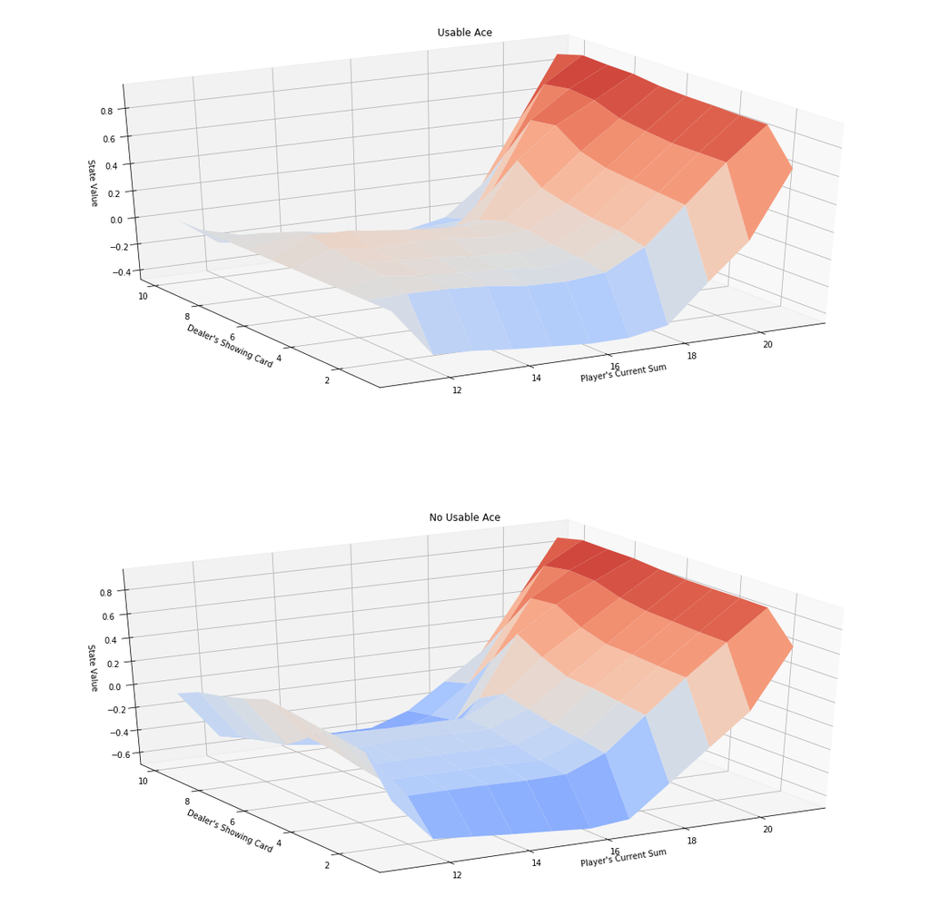

```python
# obtain the state-value function
V_glie = dict((k,np.max(v)) for k, v in Q_glie.items())

# plot the state-value function
plot_blackjack_values(V_glie)
```

Finally, we visualize the policy that is estimated to be optimal.

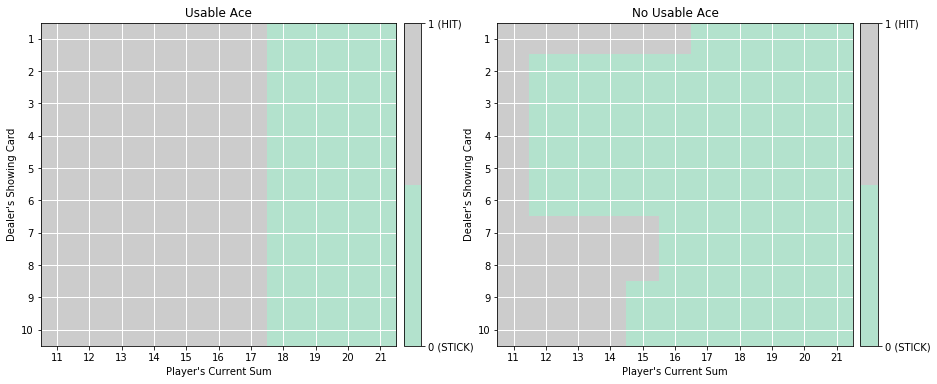

```python
# plot the policy
plot_policy(policy_glie)
```

The **true** optimal policy $\pi_*$ can be found on page 82 of the textbook (and appears below). Compare your final estimate to the optimal policy - how close are you able to get? If you are not happy with the performance of your algorithm, take the time to tweak the decay rate of $\epsilon$ and/or run the algorithm for more episodes to attain better results.

[figure not shown]

### Part 4: MC Control: Constant-$\alpha$

In this section, you will write your own implementation of constant-$\alpha$ MC control.

Your algorithm has four arguments:

- `env`: This is an instance of an OpenAI Gym environment.
- `num_episodes`: This is the number of episodes that are generated through agent-environment interaction.
- `alpha`: This is the step-size parameter for the update step.
- `gamma`: This is the discount rate. It must be a value between 0 and 1, inclusive (default value: `1`).

The algorithm returns as output:

- `Q`: This is a dictionary (of one-dimensional arrays) where `Q[s][a]` is the estimated action value corresponding to state `s` and action `a`.
- `policy`: This is a dictionary where `policy[s]` returns the action that the agent chooses after observing state `s`.

(*Feel free to define additional functions to help you to organize your code.*)

```python
def mc_control_alpha(env, num_episodes, alpha, gamma=1.0,
                    limit=18, probability=0.6):
    '''
    Takes the environment and number of episodes, along with some optional inputs,
    and returns a policy and reward estimate that will eventually converge on optimal.
    Uses a constant alpha to weight how important recent episodes are to the estimate.
    (1 ≥ alpha > 0 with 1 weighting recent episodes the most and 0 never updating the estimate)
    '''
    nA = env.action_space.n
    # initialize empty dictionary of arrays
    Q = defaultdict(lambda: np.zeros(nA))
    # loop over episodes
    for i_episode in range(1, num_episodes+1):
        # monitor progress
        if i_episode % 1000 == 0:
            print("\rEpisode {}/{}.".format(i_episode, num_episodes), end="")
            sys.stdout.flush()

        ## TODONE: complete the function

        # Setting episilon to start with a value very near 1, and finishing at 0.1
        e = 1 / ((9 * i_episode / num_episodes) + 1)

        # Generates an episilon greedy episode
        episode = greedy_e(env, Q, e, nA, limit, probability)

        # Unzip the States, Actions and Rewards from the episode
        S, A, R = zip(*episode)

        # Get a discount array based on the current gamma
        G = np.array([gamma ** t for t in range(1+len(R))])

        # Obtain the first visit MC prediction, with more recent episodes having more weight proportional to alpha
        for t, s in enumerate(S):
            q = Q[s][A[t]]
            Q[s][A[t]] = q + alpha * (sum(R[t:] * G[:-(1+t)]) - q)


    policy = dict((key, np.argmax(v)) for key, v in Q.items())

    return policy, Q
```

Use the cell below to obtain the estimated optimal policy and action-value function.

```python
# obtain the estimated optimal policy and action-value function
policy_alpha, Q_alpha = mc_control_alpha(env, 10000000, 0.01)
```

```
Episode 10000000/10000000.
```

Next, we plot the corresponding state-value function.

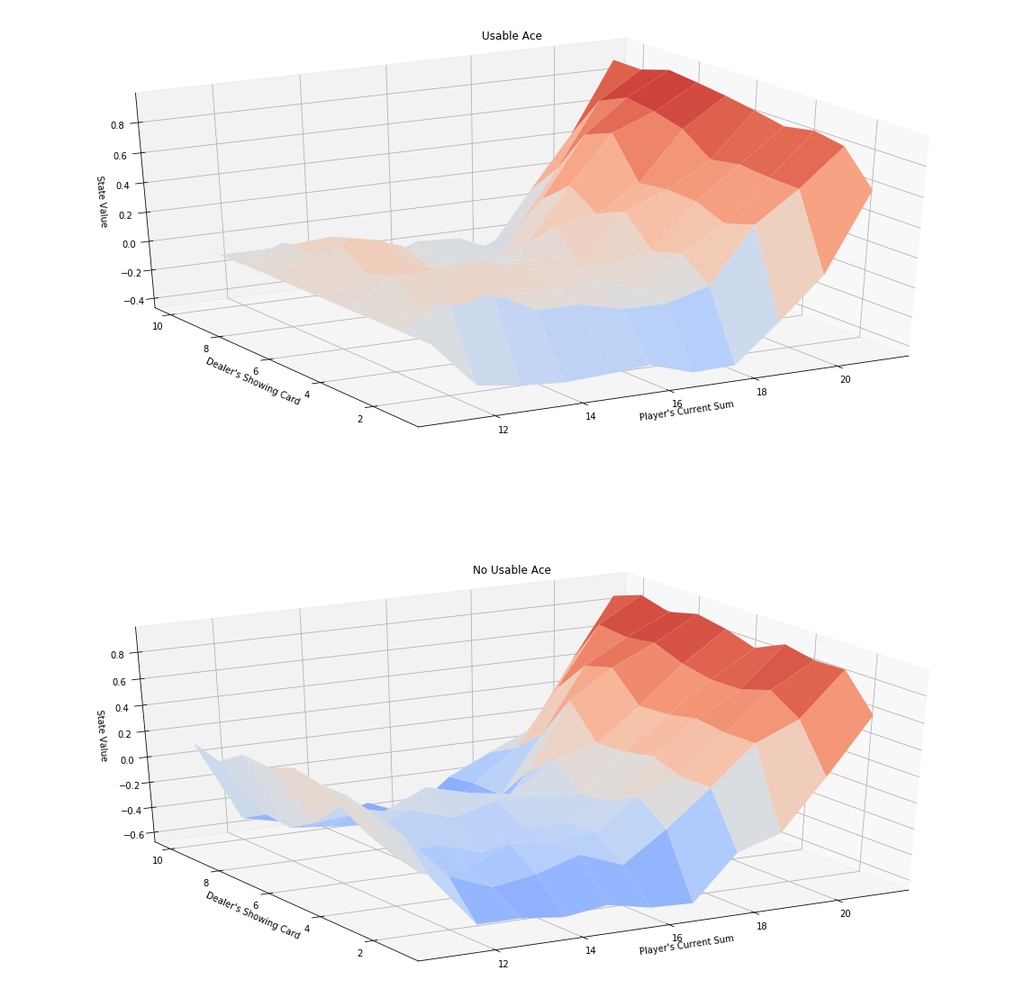

```python
# obtain the state-value function
V_alpha = dict((k,np.max(v)) for k, v in Q_alpha.items())

# plot the state-value function
plot_blackjack_values(V_alpha)
```

Finally, we visualize the policy that is estimated to be optimal.

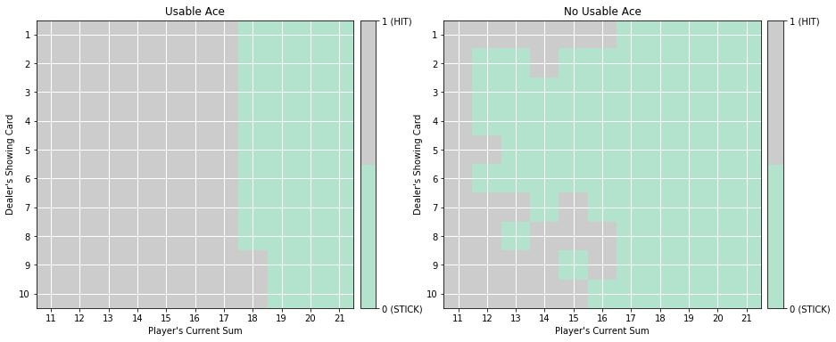

```python
# plot the policy
plot_policy(policy_alpha)
```

The **true** optimal policy $\pi_*$ can be found on page 82 of the textbook (and appears below). Compare your final estimate to the optimal policy - how close are you able to get? If you are not happy with the performance of your algorithm, take the time to tweak the decay rate of $\epsilon$, change the value of $\alpha$, and/or run the algorithm for more episodes to attain better results.

[figure not shown]